# Proposed objectives of EPL_Set.csv analysis

1. Total no. of goals per season
2. Avg. no. of goals per game
3. Total no. of wins -away,home- and draws
4. No. of seasons played by each team
5. Winners for every season
6. Most exciting matches per season and overall i.e where each team scored, game had most no. of goals for season and goal difference is at most 2 goals
7. Avg. no. of goals per game for season winner
8. Function that gives a specific teams stats(no. of goals score that season, avg. goals per game, no. of home and and away wins, fixtures) after giving team name and season as input.

# Column Name Abreviations

1. FTHG -full time home goal
2. FTAG -full time away goal
3. FTR -full time results
4. HTHG -half time home goal
5. HTAG -half time away goal
6. HTR -half time result
7. Goals_at_FT -Goals at full time

```python
from collections import Counter,OrderedDict
import pandas as pd
import numpy as np
import matplotlib.pyplot as plt
import seaborn as sns
import plotly.graph_objs as go
import cufflinks as cf
from plotly.offline import download_plotlyjs, init_notebook_mode,plot,iplot
init_notebook_mode(connected=True)
cf.go_offline()
%matplotlib inline

epl = pd.read_csv('EPL_Set.csv',delimiter=',')
epl.head()
```

|  | Div | Date | HomeTeam | AwayTeam | FTHG | FTAG | FTR | HTHG | HTAG | HTR | Season |
| --- | --- | --- | --- | --- | --- | --- | --- | --- | --- | --- | --- |
| 0 | E0 | 14/08/93 | Arsenal | Coventry | 0 | 3 | A | NaN | NaN | NaN | 1993-94 |
| 1 | E0 | 14/08/93 | Aston Villa | QPR | 4 | 1 | H | NaN | NaN | NaN | 1993-94 |
| 2 | E0 | 14/08/93 | Chelsea | Blackburn | 1 | 2 | A | NaN | NaN | NaN | 1993-94 |
| 3 | E0 | 14/08/93 | Liverpool | Sheffield Weds | 2 | 0 | H | NaN | NaN | NaN | 1993-94 |
| 4 | E0 | 14/08/93 | Man City | Leeds | 1 | 1 | D | NaN | NaN | NaN | 1993-94 |

```python
epl.info()
```

```
<class 'pandas.core.frame.DataFrame'>
RangeIndex: 9664 entries, 0 to 9663
Data columns (total 11 columns):
Div         9664 non-null object
Date        9664 non-null object
HomeTeam    9664 non-null object
AwayTeam    9664 non-null object
FTHG        9664 non-null int64
FTAG        9664 non-null int64
FTR         9664 non-null object
HTHG        8740 non-null float64
HTAG        8740 non-null float64
HTR         8740 non-null object
Season      9664 non-null object
dtypes: float64(2), int64(2), object(7)
memory usage: 830.6+ KB
```

```python
#number of null values
epl.isnull().sum()
```

```
Div           0
Date          0
HomeTeam      0
AwayTeam      0
FTHG          0
FTAG          0
FTR           0
HTHG        924
HTAG        924
HTR         924
Season        0
dtype: int64
```

|  | Div | Date | HomeTeam | AwayTeam | FTHG | FTAG | FTR | HTHG | HTAG | HTR | Season | Goals_at_FT |
| --- | --- | --- | --- | --- | --- | --- | --- | --- | --- | --- | --- | --- |
| 0 | E0 | 14/08/93 | Arsenal | Coventry | 0 | 3 | A | NaN | NaN | NaN | 1993-94 | 3 |
| 1 | E0 | 14/08/93 | Aston Villa | QPR | 4 | 1 | H | NaN | NaN | NaN | 1993-94 | 5 |
| 2 | E0 | 14/08/93 | Chelsea | Blackburn | 1 | 2 | A | NaN | NaN | NaN | 1993-94 | 3 |
| 3 | E0 | 14/08/93 | Liverpool | Sheffield Weds | 2 | 0 | H | NaN | NaN | NaN | 1993-94 | 2 |
| 4 | E0 | 14/08/93 | Man City | Leeds | 1 | 1 | D | NaN | NaN | NaN | 1993-94 | 2 |

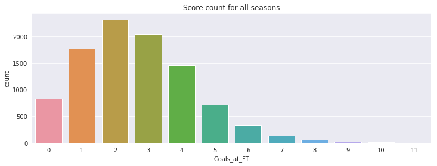

```python
#creating column for full time scores by summing home and away teams fulltime scores
epl['Goals_at_FT'] = epl['FTHG'] + epl['FTAG']

#distribution graph of total count of scores
sns.set_style('darkgrid')
sns.set_color_codes('pastel')
plt.figure(figsize=(12,4))
sns.countplot(x='Goals_at_FT',data=epl)
plt.title('Score count for all seasons')
epl.head()
```

```python
#Global variables
seasons = epl.Season.unique()
teams = epl.HomeTeam.unique()
```

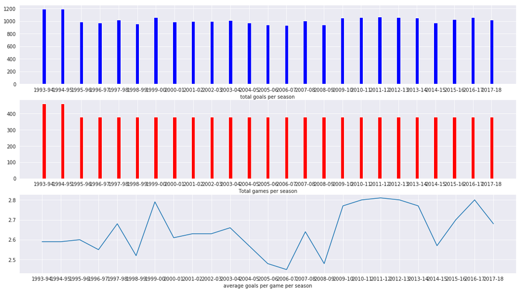

```python
# 1. Total no. of goals per season
# 2. Avg. no. of goals per game
#function to find number of games played, total goals and average goals per game in a given season
def goals_per_season():
    total_goals = []
    avg_goals_per_season = []
    games_per_season = []
    for season in seasons:
        scores = epl[epl['Season']==season]['Goals_at_FT']

        total_goals.append(sum(scores))
        avg_goals_per_season.append(round(np.mean(scores),2)) #getting mean and rounding to 2 d.p
        games_per_season.append(len(scores))

    #graph subplots showing sum of goals and games played per season, and mean goals per game per season
    fig,axes= plt.subplots(nrows=3, ncols=1,figsize=(18,10) )
    axes[0].bar(seasons,total_goals, width=0.2, color='blue', align='center', label='total_goals')
    axes[0].set_xlabel('total goals per season')

    axes[1].bar(seasons,games_per_season, width=0.2, color='red', align='center', label='games_per_season')
    axes[1].set_xlabel('Total games per season')

    axes[2].plot(seasons,avg_goals_per_season)
    axes[2].set_xlabel('average goals per game per season')

goals_per_season()
```

462 games were played during the first two seasons resulting in a total of 1200 goals per season. All subsequent seasons played 380 games with varying sum of goals per season. However, starting with the 2009-10 season onwards, total goals per season have been almost always more than previous seasons. The average goals per game have also been higher except for a dip in the 2014-15 season.There isn't enough data to explain the observation.

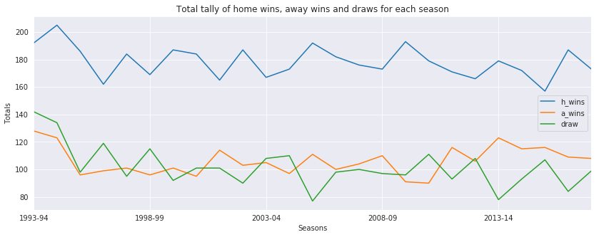

```python
# 3. Total no. of wins -away,home- and draws
#function to find no. of home and away wins and draws per season.
def wins_draws():
    h_wins = []
    a_wins = []
    draw = []
    for year in seasons:
        result = epl[epl['Season']==year][['FTR']]
        home_wins = 0
        away_wins = 0
        draws = 0
        for i in result['FTR']:
            if 'H' in i:
                home_wins += 1
            elif 'A' in i:
                away_wins += 1
            else:
                draws += 1

        h_wins.append(home_wins)
        a_wins.append(away_wins)
        draw.append(draws)

    joint=list(zip(h_wins,a_wins,draw))
    trend = pd.DataFrame(joint, index=seasons, columns='h_wins a_wins draw'.split())#creating dataframe from list
    trend.plot(figsize=(14,5))
    plt.xlabel('Seasons')
    plt.ylabel('Totals')
    plt.title('Total tally of home wins, away wins and draws for each season')

wins_draws()
```

```python
# 4. No. of seasons played by each team
new = []
for i in seasons:
    fresh = (epl[epl.Season==i]['HomeTeam']).unique()
    new.extend(fresh)

p = dict(Counter(new)) #Counter container counts no. of times each team appears in the list
q = pd.DataFrame.from_dict(p, orient='index', columns=['Total seasons played']) #creating dataframe from dict
v = q.sort_values('Total seasons played', ascending=False).reset_index()
trace = go.Bar(x=v['index'],y=v['Total seasons played'])
layout = dict(title='Total no. of seasons ever played by each team.',autosize=False,width=900,height=480,
              margin=go.layout.Margin(l=50,r=50,b=100,t=100,pad=4),bargroupgap=0.3)
fig= go.Figure(data=[trace],layout=layout)
iplot(fig)
```

[interactive chart not shown]

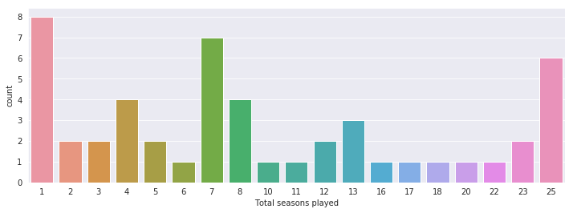

```python
plt.figure(figsize=(12,4))
sns.countplot(x='Total seasons played',data=q)
```

```python
# No. of games played by each team
team = epl[['HomeTeam','AwayTeam']]
h = team.apply(pd.Series.value_counts)
h['Total games played all seasons']=h.sum(axis=1)
z = h.sort_values('Total games played all seasons', ascending=False).reset_index()
trace2 = go.Bar(x=z['index'],y=z['Total games played all seasons'])
layout2 = dict(title='Total no. of games ever played by each team.',autosize=False,width=900,height=480,
               margin=go.layout.Margin(l=50,r=50,b=100,t=100,pad=4),bargroupgap=0.3)
fig2= go.Figure(data=[trace2],layout=layout2)
iplot(fig2)
```

[interactive chart not shown]

```
Text(0.5,1,'Count of teams and the total number of games they have played')
```

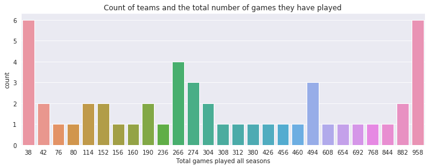

```python
plt.figure(figsize=(12,4))
sns.countplot(x='Total games played all seasons', data=h)
plt.title('Count of teams and the total number of games they have played')
```

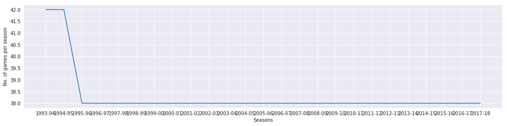

```python
#function to find number of games played by team each season
def team_games_per_season():
    games_per_season = []
    for season in seasons:
        team = epl[epl.Season==season][['HomeTeam','AwayTeam']]
        g = team.apply(pd.Series.value_counts)
        g['Total games played in season'] = g.sum(axis=1) #summing lolumns of games played at home and away
        games_per_season.append(g.iloc[0]['Total games played in season']) #no. of games played in season
    plt.figure(figsize=(18,4))
    plt.plot(seasons,games_per_season)
    plt.xlabel('Seasons')
    plt.ylabel('No. of games per season')

team_games_per_season()
```

```python
# 5. Winners for every season
def season_champs():
    season_winners = []
    season = []
    for year in seasons: #seasons is global variable
        season_info = epl[epl.Season==year]
        results = []
        team = []
        for club in teams: #teams is a global variable
            a = season_info[season_info.HomeTeam==club]  #FTR for club at home
            b = season_info[season_info.AwayTeam==club]  #FTR for club when away
            points = 0
            for result in a['FTR']:
                if 'H' in result:
                    points+=3
                elif 'D' in result:
                    points+=1
                else:
                    points+=0
            for r in b['FTR']:
                if 'A' in r:
                    points+=3
                elif 'D' in r:
                    points+=1
                else:
                    points+=0
            results.append(points)
            team.append(club)
        z = dict(zip(team,results)) #creating dict from two lists:team and results as key and value respectively
        winner = max(z, key=z.get)  #getting key of key:value pair with max value
        season_winners.append(winner)
        season.append(year)

        champs = dict(zip(season,season_winners))
    return champs,season_winners
```

```python
w = dict(Counter(season_champs()[1]))
x = pd.DataFrame.from_dict(w, orient='index')
print("Overall cup winners: ",'\n',x.sort_values(0, ascending=False))
```

```
Overall cup winners:
              0
Man United  12
Chelsea      5
Arsenal      3
Man City     3
Blackburn    1
Leicester    1
```

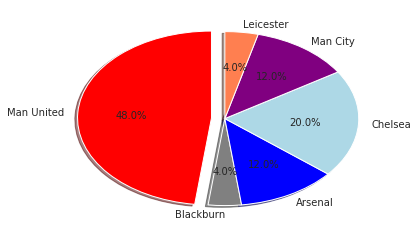

```python
#pie chart indicating no. of epl titles won by which team
colors = ['Red','gray','blue','lightblue','purple','coral']
explode = [0.1,0,0,0,0,0]
plt.pie(w.values(),labels=w.keys(),explode=explode,colors=colors,autopct='%1.1f%%',shadow=True,startangle=90)
plt.show()
```

```python
# 6. Most exciting matches per season and overall i.e where each team scored, game had most no. of goals for season
#    and goal difference is at most 2 goals
def most_exciting_games(n):
    mwaka = epl[epl.Season==n]
    gg = mwaka[(mwaka.FTHG>0) & (mwaka.FTAG>0) & ((mwaka.FTHG - mwaka.FTAG).abs()<3) & (mwaka.Goals_at_FT>5)]
    return gg

most_exciting_games('2017-18')
```

|  | Div | Date | HomeTeam | AwayTeam | FTHG | FTAG | FTR | HTHG | HTAG | HTR | Season | Goals_at_FT |
| --- | --- | --- | --- | --- | --- | --- | --- | --- | --- | --- | --- | --- |
| 9284 | E0 | 11/8/2017 | Arsenal | Leicester | 4 | 3 | H | 2.0 | 2.0 | D | 2017-18 | 7 |
| 9290 | E0 | 12/8/2017 | Watford | Liverpool | 3 | 3 | D | 2.0 | 1.0 | H | 2017-18 | 6 |
| 9365 | E0 | 21/10/17 | Chelsea | Watford | 4 | 2 | H | 1.0 | 1.0 | D | 2017-18 | 6 |
| 9416 | E0 | 28/11/17 | Watford | Man United | 2 | 4 | A | 0.0 | 3.0 | A | 2017-18 | 6 |
| 9464 | E0 | 22/12/17 | Arsenal | Liverpool | 3 | 3 | D | 0.0 | 1.0 | A | 2017-18 | 6 |
| 9474 | E0 | 26/12/17 | Bournemouth | West Ham | 3 | 3 | D | 1.0 | 1.0 | D | 2017-18 | 6 |
| 9512 | E0 | 14/01/18 | Liverpool | Man City | 4 | 3 | H | 1.0 | 1.0 | D | 2017-18 | 7 |
| 9662 | E0 | 13/05/18 | Tottenham | Leicester | 5 | 4 | H | 1.0 | 2.0 | A | 2017-18 | 9 |

A trial to determine the most exciting matches for a given season according to arbitrary conditions.

```python
# 7. Avg. no. of goals per game for season winner
def avg_goals():
    results = []
    winning_team = []
    avg_goals_per_game = []
    season = []

    for key,value in season_champs()[0].items(): #separates key(season):value(winning team) pair returned from season_champs() function
        info = epl[epl.Season==key]
        home = info[info.HomeTeam==value]
        away = info[info.AwayTeam==value]

        goals = 0
        for h in home['FTHG']: #iterates through every hometeam goal and adds it to the initialized goals variable
            goals+=h
        for a in away['FTAG']:
            goals+=a

        results.append(goals) #adds total goals of season winning team to results list
        winning_team.append(value)
        season.append(key)
        mean_goals = goals/(2*len(home)) #gives average goals per game for season
        avg_goals_per_game.append('%.2f'%mean_goals) #appends average goals rounded off to 2dp per game to list

    winner_total_goals = zip(winning_team,results,avg_goals_per_game)
    k = pd.DataFrame(winner_total_goals,index = season,columns='winning_team total_goals avg_goals_per_game'.split())
    return k
avg_goals()
```

|  | winning_team | total_goals | avg_goals_per_game |
| --- | --- | --- | --- |
| 1993-94 | Man United | 80 | 1.90 |
| 1994-95 | Blackburn | 80 | 1.90 |
| 1995-96 | Man United | 73 | 1.92 |
| 1996-97 | Man United | 76 | 2.00 |
| 1997-98 | Arsenal | 68 | 1.79 |
| 1998-99 | Man United | 80 | 2.11 |
| 1999-00 | Man United | 97 | 2.55 |
| 2000-01 | Man United | 79 | 2.08 |
| 2001-02 | Arsenal | 79 | 2.08 |
| 2002-03 | Man United | 74 | 1.95 |
| 2003-04 | Arsenal | 73 | 1.92 |
| 2004-05 | Chelsea | 72 | 1.89 |
| 2005-06 | Chelsea | 72 | 1.89 |
| 2006-07 | Man United | 83 | 2.18 |
| 2007-08 | Man United | 80 | 2.11 |
| 2008-09 | Man United | 68 | 1.79 |
| 2009-10 | Chelsea | 103 | 2.71 |
| 2010-11 | Man United | 78 | 2.05 |
| 2011-12 | Man City | 93 | 2.45 |
| 2012-13 | Man United | 86 | 2.26 |
| 2013-14 | Man City | 102 | 2.68 |
| 2014-15 | Chelsea | 73 | 1.92 |
| 2015-16 | Leicester | 68 | 1.79 |
| 2016-17 | Chelsea | 85 | 2.24 |
| 2017-18 | Man City | 106 | 2.79 |

```
Text(0.5,0,'Seasons')
```

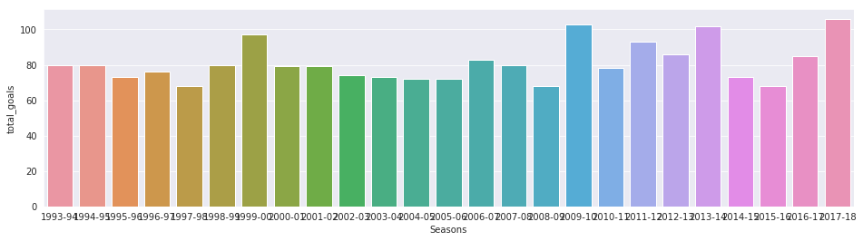

```python
plt.figure(figsize=(16,4))
sns.barplot(x='index',y='total_goals', data=avg_goals().reset_index())
plt.xlabel('Seasons')
```

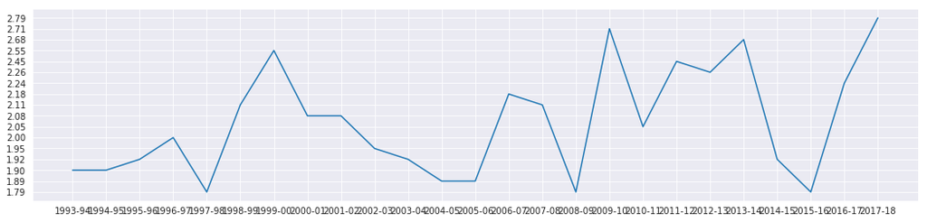

```python
plt.figure(figsize=(18,4))
plt.plot(avg_goals()[['avg_goals_per_game']])
```

```
80 total goals and
1.90 average goals per game
with 14 home win(s), 1 home loose(s),13 away win(s),
3 away loose(s) and 11 draw(s)
for Man United in 1993-94     season.
```

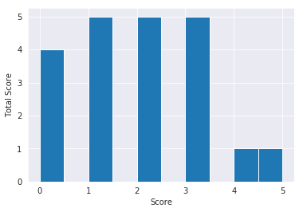

```python
# 8. Function that gives a specific teams stats(no. of goals scored that season, avg. goals per game,
# no. of home and and away wins, *fixtures(returns match details after giving opposing team's name))
# after giving team name and season as input.
def team_stats(team_name,season_played):
    #no. of goals scored that season
    team_info = epl[epl.Season==season_played]
    home_games = team_info[team_info.HomeTeam==team_name]
    away_games = team_info[team_info.AwayTeam==team_name]
    goals = 0
    for h_g in home_games['FTHG']:
        goals+=h_g
    for a_g in away_games['FTAG']:
        goals+=a_g

    #average goals per game
    avg_gpg = '%.2f'%(goals/(2*len(home_games)))

    #no. of home and away wins,draws and looses
    home_wins = 0
    home_looses = 0
    away_wins = 0
    away_looses = 0
    draws = 0
    for h_games in home_games['FTR']:
        if 'H' in h_games:
            home_wins+=1
        elif 'A' in h_games:
            home_looses+=1
        else:
            draws+=1

    for a_games in away_games['FTR']:
        if 'A' in a_games:
            away_wins+=1
        elif 'H' in a_games:
            away_looses+=1
        else:
            draws+=1

    print('{} total goals and \n{} average goals per game \nwith {} home win(s), {} home loose(s),{} away win(s),\
    \n{} away loose(s) and {} draw(s) \nfor {} in {} \
    season.'.format(goals,avg_gpg,home_wins, home_looses, away_wins, away_looses, draws, team_name, season_played))
    home_games['FTHG'].hist()
    plt.xlabel('Score')
    plt.ylabel('Total Score')

team_stats('Man United','1993-94')
```

The function gives basic statistics if given a team name and season as arguments.The statement is clear. The bar plot indicates that Manchester United tended to score between 1 and 3 goals for its home matches during the 1993-94 season. Notably, the team failed to score on only 4 occassions or 19% of the home matches.

```python
isnew = epl[['FTHG','FTAG','Goals_at_FT']]
isnew.head()
```

|  | FTHG | FTAG | Goals_at_FT |
| --- | --- | --- | --- |
| 0 | 0 | 3 | 3 |
| 1 | 4 | 1 | 5 |
| 2 | 1 | 2 | 3 |
| 3 | 2 | 0 | 2 |
| 4 | 1 | 1 | 2 |

```python
trace3 = go.Histogram(x=isnew['FTHG'],name='FTHG',opacity=0.75)
trace4 = go.Histogram(x=isnew['FTAG'],name='FTAG',opacity=0.75)
trace5 = go.Histogram(x=isnew['Goals_at_FT'],name='Goals_at_FT',opacity=0.75)
layout3 = dict(title='Overlaid histogram of total goals per score',barmode='overlay',autosize=False,width=900,height=480,
               margin=go.layout.Margin(l=50,r=50,b=100,t=100,pad=4),bargroupgap=0.3)
fig3= go.Figure(data=[trace3,trace4,trace5],layout=layout3)
iplot(fig3)
```

[interactive chart not shown]

Toggling between the histograms by clicking the legend elements reveals histograms of FTHG, FTAG and Goals_at_FT. The FTHG histogram shows that teams playing at home generally score with most goals being either 1 or 2 with the highest score being 9 goals on two occasions. The FTAG histogram indicates that teams play away matches generally score 1 goal or leave goaless.However, there have been great upsets with away teams thrashing their hosts 6 goals or more on 27 occassions with the highest being 8 goals in one match. The Goals_at_FT reveal that few matches end goaless with most scores between 1 and 4. There have also been notable results of over 7 goals with the highest being 11 goals but only in one match.

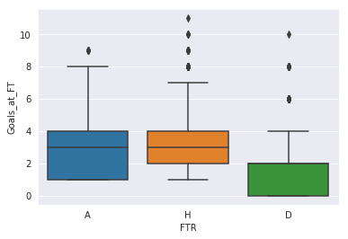

```python
sns.boxplot(x='FTR', y='Goals_at_FT',data=epl)
```